# ИДЗ №3 Простая регрессия

Федоров Илья 8383

19.12.2020

### Вариант 23

Результаты статистического эксперимента приведены в таблице 1. Требуется оценить характер зависимости переменной *Y* от переменное *X*.
$$\alpha_1=0.10; \ \ h=3.00$$

**Таблица 1**

| N | Y | X |
| --- | --- | --- |
| 1 | 5.96 | 4 |
| 2 | 9.55 | 3 |
| 3 | 10.54 | 3 |
| 4 | 6.43 | 4 |
| 5 | 17.52 | 6 |
| 6 | 9.86 | 0 |
| 7 | 5.11 | 2 |
| 8 | 3.45 | 5 |
| 9 | 14.99 | 4 |
| 10 | 2.70 | 7 |
| 11 | 11.05 | 3 |
| 12 | 17.49 | 4 |
| 13 | 3.79 | 3 |
| 14 | 12.30 | 5 |
| 15 | 4.91 | 2 |
| 16 | 9.76 | 2 |
| 17 | 6.50 | 3 |
| 18 | 22.16 | 2 |
| 19 | 2.20 | 3 |
| 20 | 14.53 | 4 |
| 21 | 4.77 | 3 |
| 22 | 18.85 | 6 |
| 23 | 13.68 | 5 |
| 24 | 6.07 | 3 |
| 25 | 0.05 | 2 |
| 26 | 1.51 | 4 |
| 27 | 6.97 | 2 |
| 28 | 6.55 | 3 |
| 29 | 0.55 | 2 |
| 30 | 14.37 | 3 |
| 31 | 11.23 | 4 |
| 32 | 12.52 | 4 |
| 33 | 13.92 | 3 |
| 34 | 18.33 | 1 |
| 35 | 2.35 | 6 |
| 36 | 8.86 | 3 |
| 37 | 2.15 | 3 |
| 38 | 24.09 | 3 |
| 39 | 17.61 | 4 |
| 40 | 6.96 | 4 |
| 41 | 5.68 | 5 |
| 42 | 5.82 | 3 |
| 43 | 8.65 | 6 |
| 44 | 6.36 | 3 |
| 45 | 14.05 | 4 |
| 46 | 12.20 | 6 |
| 47 | 8.01 | 3 |
| 48 | 1.86 | 4 |
| 49 | 13.28 | 3 |
| 50 | 8.46 | 5 |

### **Задание 1**

Построить графически результаты эксперимента. Сформулировать линейную регрессионную модель переменной *Y* по переменной *X*. Построить МНК оценки параметров сдвига $\beta_0$ и масштаба $\beta_1$. Построить полученную линию регрессии. Оценить визуально соответствие полученных данных и построенной оценки.

*Решение:* Результаты эксперимента и линия регрессии показаны на рис. 1.

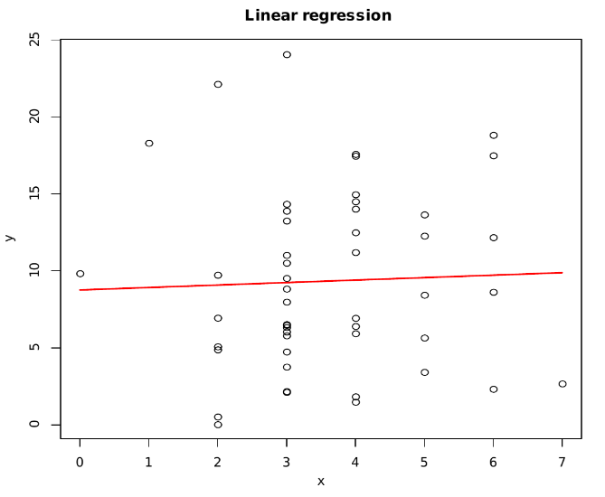

| **Рисунок 1** |
| --- |

Линейная регрессионная модель имеет вид: $y_i = \beta_1x_i + \beta_0 + \epsilon_i$. Найдем МНК оценки параметров регресии $\beta_0$ и $\beta_1$:
$$F(\beta_1,\beta_0) = \sum_{i=1}^n(y_i-\hat{y_i})^2 = \sum_{i=1}^n\epsilon_i^2 \rightarrow min$$

$$\begin{cases}
\cfrac{\partial F}{\partial\beta_0} = -2\sum_{i=1}^n(y_i-\beta_0-\beta_1x_i) = 0 \\
\cfrac{\partial F}{\partial\beta_1} = -2\sum_{i=1}^n(y_i-\beta_0-\beta_1x_i)x_i = 0
\end{cases}$$

$$\begin{cases}
n\beta_0 + \beta_1\sum_{i=1}^nx_i = \sum_{i=1}^ny_i \\
\beta_0\sum_{i=1}^nx_i + \beta_1\sum_{i=1}^nx_i^2 = \sum_{i=1}^ny_ix_i
\end{cases}$$

Решив систему получим оценки параметров регрессии:
$$\hat\beta_1 = \cfrac{\overline{xy} - \overline{x}\cdot\overline{y}}{\overline{x^2} - \overline{x}^2} = 0.160482$$

$$\hat\beta_0 = \overline{y} - \beta_1\overline{x}= 8.756673$$
Получим линию регрессии: $\hat{y} = 0.160482x + 8.756673$.

### **Задание 2**

Построить и интерпретировать несмещенную оценку дисперсии. На базе ошибок построить гистограмму с шагом *h*. Проверить гипотезу нормальности ошибок на уровне $\alpha_1$ по $\chi^2$. Оценить расстроение полученной оценки до класса нормальных распределений по Колмогорову.

*Решение:* Вычислим несмещенную оценку дисперсии:
$$\sigma^2 = \cfrac{1}{n-2}\sum_{i=1}^n(y_i-\overline{y}) = 34.3382$$
Построим на базе ошибок гистограмму с заданным шагом *h*=3.

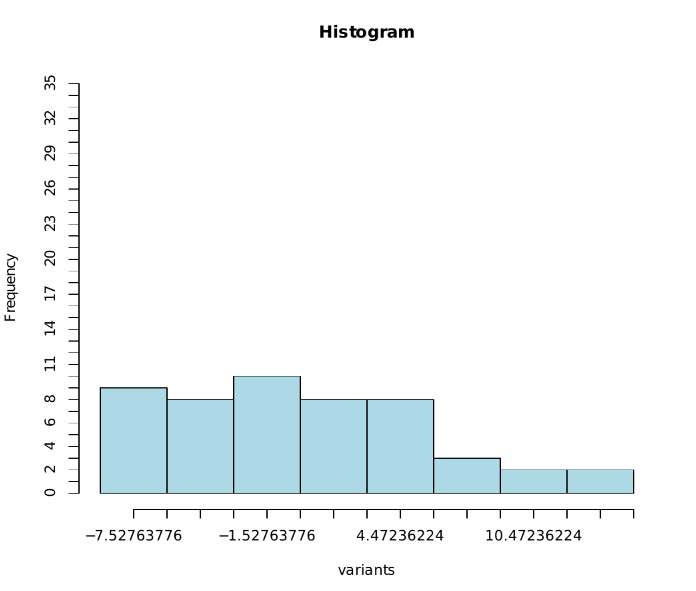

| **Рисунок 2** |
| --- |

Проверим гипотезу нормальности на уровне $\alpha_1 = 0.1$ по $\chi^2$. Для проверки воспользуемся следующим кодом R:

```r
res         # ошибки
h <- 3      # шаг
k <- ceiling((max(res)-min(res))/h) #число интервалов
brk<-min(res)+c(0:k)*h      #интервалы
brk[1] = -Inf;
brk[length(brk)] = Inf;
nu<-hist(res,breaks=brk,plot=FALSE)$counts
csq0<-function(s){
    if (s>0){
        p<-pnorm(brk[2:length(brk)],0,s)-pnorm(brk[1:(length(brk)-1)],0,s)
        return(sum((nu-n*p)^2/n/p))
     } else {
        return(Inf)
       }
}
csq.s<-nlm(csq0,p=sqrt(s2))$minimum
```

С помощью приведенного ниже кода на языке R оценим расстояние полученной оценки до класса нормальных распределений по Колмогорову:

```r
s2    # несмещенная оценка дисперсии
kolm.stat<-function(s){
    sres<-sort(res)
    fdistr<-pnorm(sres,0,s)
    max(abs(c(0:(n-1))/n-fdistr),abs(c(1:n)/n-fdistr))
}
ks.dist<-nlm(kolm.stat,p=sqrt(s2))$minimum
```

Получим $D_n = 0.08541656$. Если принять $\alpha = \alpha_1 = 0.1$, то $\lambda_\alpha = 1.1992$ и $\sqrt{n}D_n < \lambda_\alpha$.

### **Задание 3**

В предположении нормальности ошибок построить доверительные интервалы для параметров $\beta_0$ и $\beta_1$ уровня доверия $1-\alpha_1$. Построить доверительный эллипс уровня доверия $1-\alpha_1$ для $(\beta_0,\beta_1)$ (вычислить его полуоси).

*Решение:* Построим доверительные интервалы в предположении о нормальности распределении ошибок: Статистики имеют распределение Стьюдента n-2:

$$t = \cfrac{\hat\beta_1 - \beta_1}{S_{\beta_1}} \sim t_{n-2} \\
t = \cfrac{\hat\beta_0 - \beta_0}{S_{\beta_0}} \sim t_{n-2} \\
S_{\beta_1}^2 = \cfrac{\sum_1^n\epsilon_i^2}{(n-2)\sum_1^n(x_i-\overline{x})^2} \\
S_{\beta_0}^2 = \cfrac{\sum_1^n\epsilon_i^2 \cfrac{1}{n}\sum_1^nx_i^2}{(n-2)\sum_1^n(x_i-\overline{x})^2} \\$$
Для уровня значимости $1-\alpha_1 = 0.9$:
$$P(-t_{1-\alpha_1/2} < \cfrac{\hat\beta_0 - \beta_0}{S_{\beta_0}} < t_{1-\alpha_1/2}) = 1- \alpha_1 \\
P(-t_{1-\alpha_1/2} < \cfrac{\hat\beta_1 - \beta_1}{S_{\beta_1}} < t_{1-\alpha_1/2}) = 1- \alpha_1 \Longrightarrow$$

$$P(\hat{\beta_0} - t_{1-\alpha_1/2} S_{\beta_0} < \beta_0 < \hat{\beta_0} + t_{1-\alpha_1/2} S_{\beta_0}) = 1+\alpha_1 \\
P(\hat{\beta_1} - t_{1-\alpha_1/2} S_{\beta_1} < \beta_1 < \hat{\beta_1} + t_{1-\alpha_1/2} S_{\beta_1}) = 1+\alpha_1 \Longrightarrow$$

Вычислим доверительные интервалы с помощью функции Octave `regress(y,x,[alpha])`:

```matlab
alpha_1 = 0.1
[b,bint,r] = regress(y',x', alpha_1)
```

Получили интервалы: $\beta_0 \in [4.9122; 12.6011]$ и $\beta_1 \in [-0.8409; 1.16181]$

Построим доверительный эллипс уровня доверия $1-\alpha_1$ для $(\beta_0,\beta_1)$. Введем функцию : $\psi = C^T\beta$. Тогда имеем:
$$C=\begin{pmatrix} 1 & 0 \\ 0 & 1 \end{pmatrix}, \ \ \hat{\psi} = \begin{pmatrix} \hat{\beta_0} \\ \hat{\beta_1} \end{pmatrix}, \ \ \hat{\psi} \sim N(\psi, \sigma^2B), \ \text{где} \ \ B=C^TS^{-1}C, \ \ S=(XX^T)$$
$$\cfrac{(\hat{\psi} - \psi)^T(C^T(XX^T)^{-1}C)^{-1}(\hat{\psi} - \psi)}{\sigma^2} \sim \chi^2_q, \ \ \text{где} \ \ q=rk(B) = 2.$$
Тогда:
$$\cfrac{(\hat{\psi} - \psi)^T(C^T(XX^T)^{-1}C)^{-1}(\hat{\psi} - \psi)}{qs^2} \sim F_{q,n-2}, \ \ F-\text{распределение Фишера-Снедекора.}$$
Тогда область
$$A_{\alpha_1} = \{ \psi: (\hat{\psi} - \psi)^T(C^T(XX^T)^{-1}C)^{-1}(\hat{\psi} - \psi) \leq s^2qx_{\alpha_1}\}, \ \ \text{} \ \ s^2 = \cfrac{SS_e}{n-2}, SS_e = ||Y-X^{T}\beta||^2$$
где $x_{\alpha_1}: F_{q,n-2}(x_{\alpha_1})=1-\alpha$, – $q$-мерный доверительный эллипсоид (в данном случае $q=2$, поэтому это эллипс). Подставив значения получим: $50b_0^2 + 358b_0b_1 + 737b_1^2 \leq s^2qx_{\alpha_1}$, где $b_0 = (\beta_0-\hat{\beta_0}), \ \ b_1= (\beta_1 - \hat{\beta_1})$.

Приведя к каноническому виду получим полуоси *a* = 3.17420798 и *b* = 0.2819032.

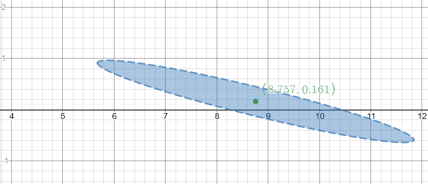

| **Рисунок 3** |
| --- |

### **Задание 4**

Сформулировать гипотезу независимости переменной *Y* от переменной *X*. Провести проверку значимости.

*Решение:* Сформулируем нулевую гипотезу:
$$\hat{\psi} \sim N(\psi, \sigma^2(C^T(XX^T)^{-1}C)) \\
H_0: \psi=C^T\beta=0, \text{параметры регрессии равны 0}. \\$$
Для проверки данной гипотезы воспольуемся *F*-критерием, статистика *F*-критерия:
$$\mathbb{F} = \cfrac{\hat{\psi}^T(C^T(XX^T)^{-1}C)^{-1}\hat{\psi}}{qs^2},$$
При справедливости $H_0$ статистика $\mathbb{F}$ имеет распределение Фишера-Снедекора $F_{q,n-2}$. Рассчитаем статистику и критическое значение $x_{\alpha_1}$ с помощью следующего кода R:

```r
# часть параметров повторяется с предыдущими пунктами
n<-length(Y); r<-dim(X)[1]; # число наблюдений и параметров
S<-X%*%t(X);   # S = XX^t
S1<-solve(S);
bht<-S1%*%X%*%Y;    # МНК-оценка
res<- Y-t(X)%*% bht  # ошибки
SSE <-sum(res^2)     # Сумма квадратов ошибок
sht<- SSE/(n-r)     #Оценка дисперсии
B<-t(C)%*%S1%*%C    # Матрица B
q<-dim(C)[1]        # Число ограничений на параметры
pht<- t(C)%*%bht    # hat-psi
SSH <- t(pht)%*%solve(B)%*%pht
F<-SSH/q/sht         #  F-статистика
f<-qf(1-0.01,q,(n-r))    # Критическое значение
```

Получим что статистика $\mathbb{F} = 0.07425469$, $x_{\alpha} = 5.07664$, отсюда $\mathbb{F}<x_{\alpha}$, принимаем гипотезу о независимости.

P.S. Как оказалось, для подобной проверки можно было воспользоваться функцией `summary(lm(y~x))$fstatistic` языка R, которая вернет нам значение F-статистики.

### **Задание 5**

Сформулировать модель, включающую дополнительный член с $X^2$. Построить МНК оценки параметров $\beta_1,\beta_2,\beta_3$ в данной модели. Изобразить графически полученную регрессионную зависимость.

*Решение:* Квадратичная регрессионная модель будет иметь вид:
$$y_i = \beta_1+\beta_2x_i+\beta_3x_i^2+\epsilon_i, \ \ \text{где } \ \epsilon_i \sim N(0,\sigma^2)$$
Найдем МНК оценки параметров регрессии $\beta_1,\beta_2,\beta_3$ с помощью функции `lm()` языка R:

```r
result <- lm(y~I(x)+I(x^2))
print(result)
```

```
##
## Call:
## lm(formula = y ~ I(x) + I(x^2))
##
## Coefficients:
## (Intercept)         I(x)       I(x^2)
##     9.15779     -0.08828      0.03321
```

Получили линию регрессии $\hat{y} = 0.03321x^2-0.08828x+9.15779$. Результаты статистического эксперимента и полученная линия регрессии показаны на рисунке 4.

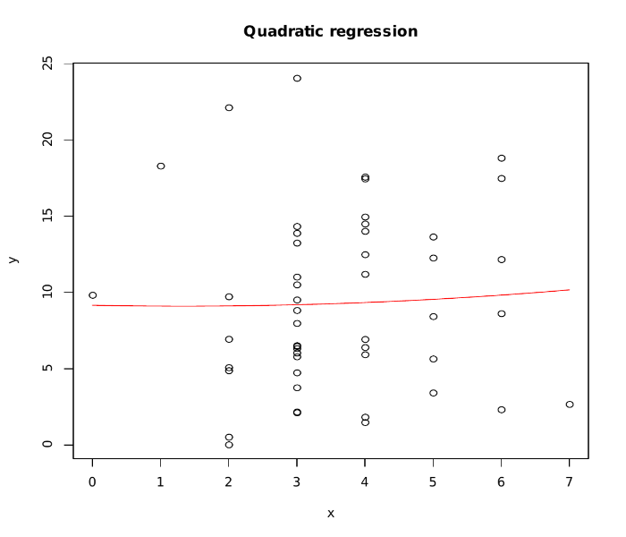

| **Рисунок 4** |
| --- |

### **Задание 6**

Построить несмещенную оценку дисперсии. Провести исследования нормальности ошибок как в п.2.

*Решение:* Вычислим несмещенную оценку дисперсии:
$$\sigma^2 = \cfrac{n-3}{n} s^2 = 32.9827448, \ \ \text{где} \ \ s^2 = s^2 = \cfrac{SS_e}{n-2}, SS_e = ||Y-X^{T}\beta||^2$$
Аналогично пункту 2 построим гистрограмму с заданным шагом $h=3.0$.

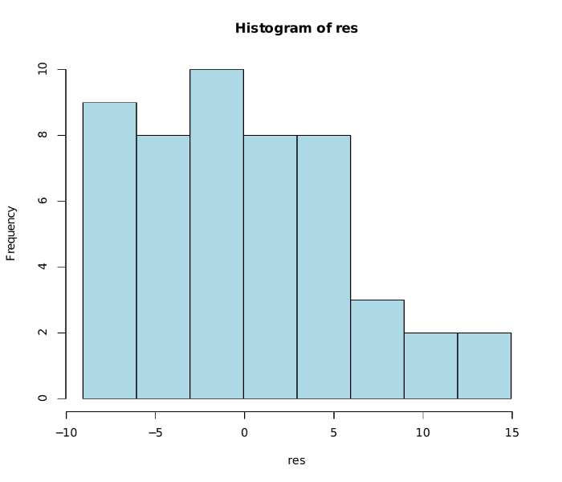

| **Рисунок 5** |
| --- |

```r
res<-Y-t(X)%*%as.matrix(bhat)   #ошибки, bhat - вектор параметров регрессии
h = 3.0        #заданный шаг
hist(res, breaks=seq(min(res), max(res)+h,by=h), col="lightblue")
```

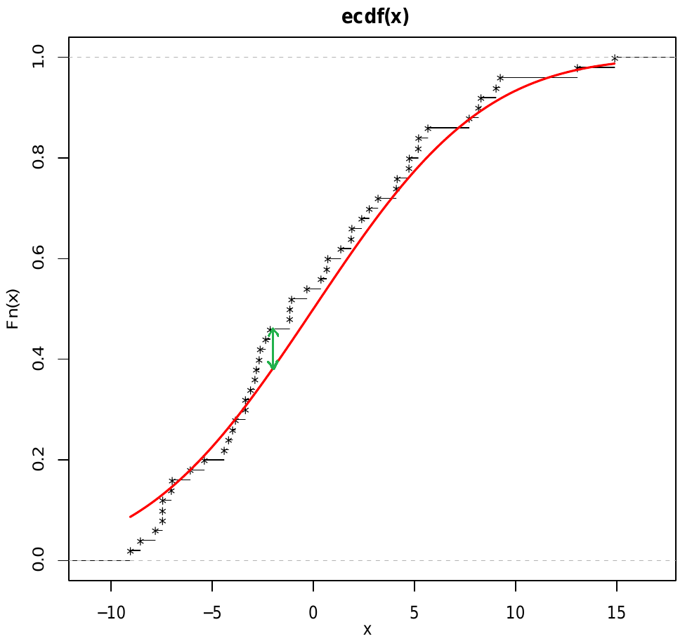

| **Рисунок 6** |
| --- |

### **Задание 7**

В предположении нормальности ошибок построить доверительные интервалы для параметров $\beta_1,\beta_2,\beta_3$ уровня $1-\alpha_1$. Написать уравнение доверительного эллипсоида уровня доверия $1-\alpha_1$.

*Решение:* аналогично пункту 3 имеем, что область
$$A_{\alpha_1} = \{ \psi: (\hat{\psi} - \psi)^T(C^T(XX^T)^{-1}C)^{-1}(\hat{\psi} - \psi) \leq s^2qx_{\alpha_1}\}, \ \ \text{} \ \ s^2 = \cfrac{SS_e}{n-2}, SS_e = ||Y-X^{T}\beta||^2$$
где $x_{\alpha_1}: F_{q,n-2}(x_{\alpha_1})=1-\alpha$, – $q$-мерный доверительный эллипсоид. В случае $q=1$ можно построить доверительный интервал на базе распределения Стьюдента:

Подставив значения и рассчитав, получим для эллипсоида : $50b_1^2 +737b_2^2 + 16649b_3^2 + 358b_1b_2 + 1474b_1b_3 + 6718b_2b_3 \leq s^23x_{\alpha_1} = 503.168$, где $b_1= (\beta_1-\hat{\beta_1})$, $b_2= (\beta_2 - \hat{\beta_2})$, $b_3= (\beta_3-\hat{\beta_3})$.

### **Задание 8**

Сформулировать гипотезу линейной регрессионной зависимости переменной *Y* от переменной *X* и проверить ее на уровне $\alpha$.

*Решение:* аналогично пункту 4, если в качестве нулевой гипотезы взять:
$$H_0: \psi=C^T\beta=0$$
при альтернативной:
$$H_1: \exists i: 1 \leq i \leq p-1: \beta_i \not = 0$$

и воспользоваться функцией `summary(lm(y~I(x)+I(x^2)))$fstatistic`, получим значение F-статистики $F=0.04148913$, $x_{\alpha} = 5.087373$, отсюда что $F<x_{\alpha}$, принимаем гипотезу о независимости.

Если воспользоваться функцией `summary()` (или `coeftest(model)` только для нужной информации), то можно получить следующие результаты:

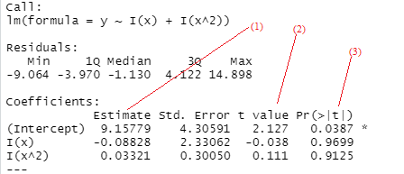

| **Рисунок 7** |
| --- |

Здесь мы получили отчет о модели, где *(1)* - оценки коэффициентов, *(2)* - значения t-статистик, которые проверяют гипотезы о незначимости каждого коэффициента (в условии $H_0$ они имеют распределение Стьюдента) и в *(3)* можно увидеть что гипотеза о том, что $\hat\beta_1 = 0$ отвергается, а гипотезы о том, что $\hat\beta_2=0, \ \hat\beta_3=0$ принимаются, то есть, *y* не зависит от *x*.